# Project_Personal_Loan_Campaign_Modelling_Final_02102021

#### Insight:

- Income, CCAvg and Mortgage are skewed, but we will not treat it to avoid bias

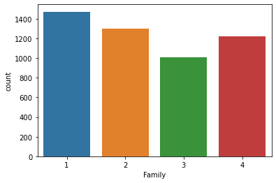

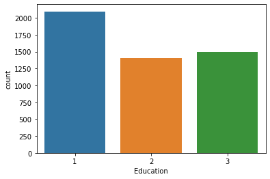

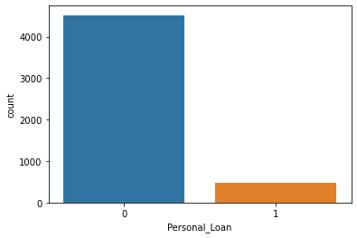

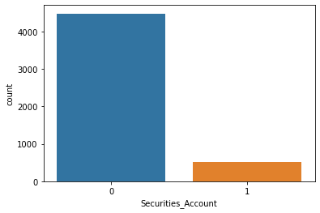

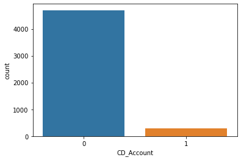

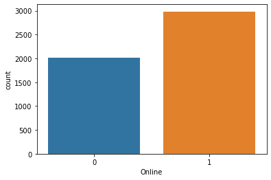

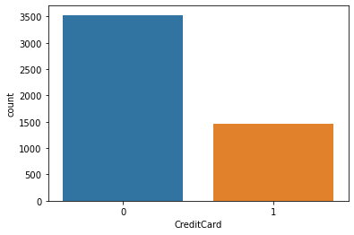

```python
#countplot for categorical columns except county
#for i in list(dsBank.drop(['County'],axis=1).columns[dsBank.drop(['County'],axis=1).dtypes =='category']):
for i in ['Family','Education','Personal_Loan','Securities_Account','CD_Account','Online','CreditCard']:
    sns.countplot(dsBank[i])
    plt.show()
```

#### Insight:

- Family size 1 has highest count and 3 has lowest count
- Education category 1 (Undergrad) has more count than others
- Personal_Loan is the target variable and the % that took Personal Loan is small
- Securities_Account, number of customers having Securities Account is smaller
- CD_Account, number of customers having CD Account is smaller
- Online, number of customers using internet banking is slightly more
- CreditCard, number of customers using Credit card is less

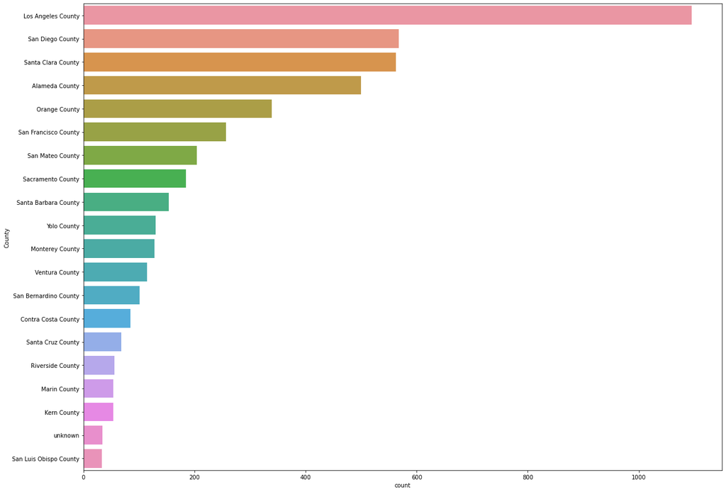

```python
#countplot for categorical column County
plt.figure(figsize= (20,15))
sns.countplot(y=dsBank['County'], order=pd.value_counts(dsBank['County']).iloc[:20].index);
```

#### Insight:

More data appears to be in these counties -> Los Angeles,San Diego,Santa Clara,Alameda

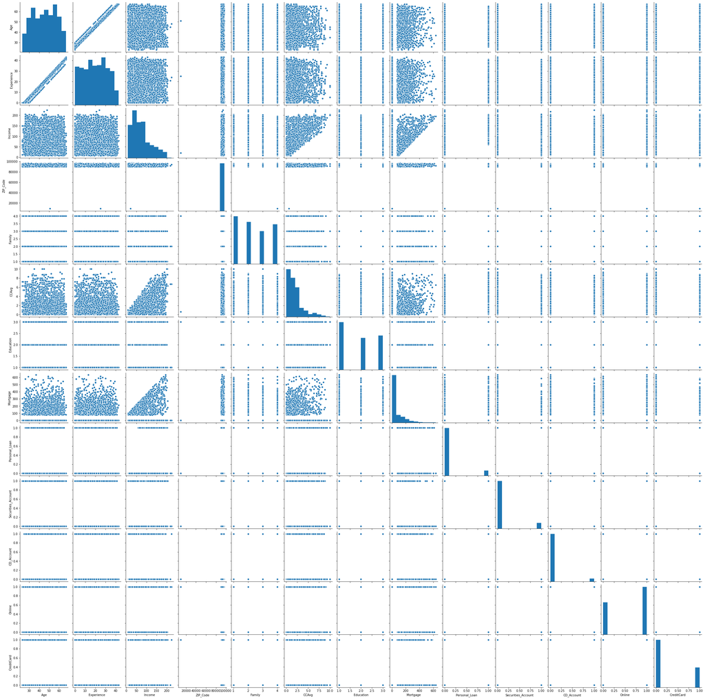

```python
#Bivariate pairplot
sns.pairplot(dsBank);
```

```python
#Correlation
dsBank.corr()
```

|  | Age | Experience | Income | ZIP_Code | Family | CCAvg | Education | Mortgage | Personal_Loan | Securities_Account | CD_Account | Online | CreditCard |
| --- | --- | --- | --- | --- | --- | --- | --- | --- | --- | --- | --- | --- | --- |
| Age | 1.000000 | 0.994198 | -0.055269 | -0.029216 | -0.046418 | -0.052012 | 0.041334 | -0.012539 | -0.007726 | -0.000436 | 0.008043 | 0.013702 | 0.007681 |
| Experience | 0.994198 | 1.000000 | -0.046729 | -0.028783 | -0.052213 | -0.049912 | 0.013536 | -0.010840 | -0.007858 | -0.001111 | 0.010046 | 0.013975 | 0.008910 |
| Income | -0.055269 | -0.046729 | 1.000000 | -0.016410 | -0.157501 | 0.645984 | -0.187524 | 0.206806 | 0.502462 | -0.002616 | 0.169738 | 0.014206 | -0.002385 |
| ZIP_Code | -0.029216 | -0.028783 | -0.016410 | 1.000000 | 0.011778 | -0.004061 | -0.017377 | 0.007383 | 0.000107 | 0.004704 | 0.019972 | 0.016990 | 0.007691 |
| Family | -0.046418 | -0.052213 | -0.157501 | 0.011778 | 1.000000 | -0.109275 | 0.064929 | -0.020445 | 0.061367 | 0.019994 | 0.014110 | 0.010354 | 0.011588 |
| CCAvg | -0.052012 | -0.049912 | 0.645984 | -0.004061 | -0.109275 | 1.000000 | -0.136124 | 0.109905 | 0.366889 | 0.015086 | 0.136534 | -0.003611 | -0.006689 |
| Education | 0.041334 | 0.013536 | -0.187524 | -0.017377 | 0.064929 | -0.136124 | 1.000000 | -0.033327 | 0.136722 | -0.010812 | 0.013934 | -0.015004 | -0.011014 |
| Mortgage | -0.012539 | -0.010840 | 0.206806 | 0.007383 | -0.020445 | 0.109905 | -0.033327 | 1.000000 | 0.142095 | -0.005411 | 0.089311 | -0.005995 | -0.007231 |
| Personal_Loan | -0.007726 | -0.007858 | 0.502462 | 0.000107 | 0.061367 | 0.366889 | 0.136722 | 0.142095 | 1.000000 | 0.021954 | 0.316355 | 0.006278 | 0.002802 |
| Securities_Account | -0.000436 | -0.001111 | -0.002616 | 0.004704 | 0.019994 | 0.015086 | -0.010812 | -0.005411 | 0.021954 | 1.000000 | 0.317034 | 0.012627 | -0.015028 |
| CD_Account | 0.008043 | 0.010046 | 0.169738 | 0.019972 | 0.014110 | 0.136534 | 0.013934 | 0.089311 | 0.316355 | 0.317034 | 1.000000 | 0.175880 | 0.278644 |
| Online | 0.013702 | 0.013975 | 0.014206 | 0.016990 | 0.010354 | -0.003611 | -0.015004 | -0.005995 | 0.006278 | 0.012627 | 0.175880 | 1.000000 | 0.004210 |
| CreditCard | 0.007681 | 0.008910 | -0.002385 | 0.007691 | 0.011588 | -0.006689 | -0.011014 | -0.007231 | 0.002802 | -0.015028 | 0.278644 | 0.004210 | 1.000000 |

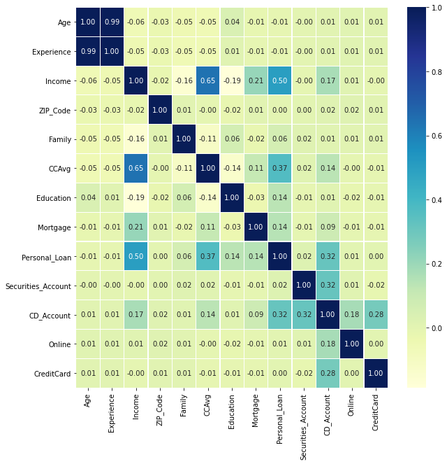

```python
#Heatmap of correlation
fig, ax = plt.subplots(figsize=(10,10));
sns.heatmap(dsBank.corr(),annot=True,linewidths=0.1,cmap='YlGnBu',fmt='.2f');
```

#### Insight:

From the pairplots and correlation heatmap, there are some association between attributes

- Between Age and Experience
- Between Income and CCAvg, Income and Personal_loan
- Personal_Loan is our target variable, that shows some association with Income, CCAvg and CD_account
- Correlation of ZIP_Code need not be considered, since that is more of a category, so decided to keep this variable in the model and see how it impacts the model using coefficient

```python
#Correlation for the target variable alone
dsBank.corr()['Personal_Loan']
```

```
Age                  -0.007726
Experience           -0.007858
Income                0.502462
ZIP_Code              0.000107
Family                0.061367
CCAvg                 0.366889
Education             0.136722
Mortgage              0.142095
Personal_Loan         1.000000
Securities_Account    0.021954
CD_Account            0.316355
Online                0.006278
CreditCard            0.002802
Name: Personal_Loan, dtype: float64
```

#### Insight:

- Personal_Loan is our target variable, that shows some association with Income, CCAvg and CD_account
- Correlation of ZIP_Code need not be considered, since that is more of a category, so decided to keep this variable in the model and see how it impacts the model using coefficient

```python
#Calculate personal_loan ratio of True/False from outcome variable
print(len(dsBank[dsBank['Personal_Loan'] == 1]))
print(len(dsBank[dsBank['Personal_Loan'] == 0]))

print()

print(len(dsBank[dsBank['Personal_Loan'] == 1])/len(dsBank) * 100)
print(len(dsBank[dsBank['Personal_Loan'] == 0])/len(dsBank) * 100)
```

```
480
4520

9.6
90.4
```

#### Insight:

- Out of 5000 customers, 480 took personal loan and 4520 did not
- % of customers who took personal loan is 9.6% and who did not is 90.4%

```python
#Bivariate Analysis - let us look at how our target variable (Personal_Loan) is distributed amongst continuous variables
dsBank[['Age','Experience','Income','CCAvg','Mortgage','Personal_Loan']].groupby(['Personal_Loan']).mean()
```

| Personal_Loan | Age | Experience | Income | CCAvg | Mortgage |
| --- | --- | --- | --- | --- | --- |
| 0 | 45.367257 | 20.148894 | 66.237389 | 1.729009 | 51.789381 |
| 1 | 45.066667 | 19.843750 | 144.745833 | 3.905354 | 100.845833 |

```python
dsBank[['Age','Experience','Income','CCAvg','Mortgage','Personal_Loan']].groupby(['Personal_Loan']).median()
```

| Personal_Loan | Age | Experience | Income | CCAvg | Mortgage |
| --- | --- | --- | --- | --- | --- |
| 0 | 45.0 | 20.0 | 59.0 | 1.4 | 0.0 |
| 1 | 45.0 | 20.0 | 142.5 | 3.8 | 0.0 |

#### Insight:

- When we see the mean and median of continuos variables with respect to the target variable, we can see that Age and Experience have no major difference between Personal_Loan = 0 or Personal_Loan = 1
- But Income, CCAvg and Mortgage (from mean only) is higher for Personal_Loan = 1

```python
#Bivariate Analysis - let us look at how our target variable (Personal_Loan) is distributed amongst categorical variables
pd.crosstab(dsBank['Family'],dsBank['Personal_Loan'],normalize='index')
```

| Personal_Loan Family | 0 | 1 |
| --- | --- | --- |
| 1 | 0.927310 | 0.072690 |
| 2 | 0.918210 | 0.081790 |
| 3 | 0.868317 | 0.131683 |
| 4 | 0.890344 | 0.109656 |

```python
pd.crosstab(dsBank['Education'],dsBank['Personal_Loan'],normalize='index')
```

| Personal_Loan Education | 0 | 1 |
| --- | --- | --- |
| 1 | 0.955630 | 0.044370 |
| 2 | 0.870278 | 0.129722 |
| 3 | 0.863424 | 0.136576 |

```python
pd.crosstab(dsBank['Securities_Account'],dsBank['Personal_Loan'],normalize='index')
```

| Personal_Loan Securities_Account | 0 | 1 |
| --- | --- | --- |
| 0 | 0.906208 | 0.093792 |
| 1 | 0.885057 | 0.114943 |

```python
pd.crosstab(dsBank['CD_Account'],dsBank['Personal_Loan'],normalize='index')
```

| Personal_Loan CD_Account | 0 | 1 |
| --- | --- | --- |
| 0 | 0.927629 | 0.072371 |
| 1 | 0.536424 | 0.463576 |

```python
pd.crosstab(dsBank['Online'],dsBank['Personal_Loan'],normalize='index')
```

| Personal_Loan Online | 0 | 1 |
| --- | --- | --- |
| 0 | 0.90625 | 0.09375 |
| 1 | 0.90248 | 0.09752 |

```python
pd.crosstab(dsBank['CreditCard'],dsBank['Personal_Loan'],normalize='index')
```

| Personal_Loan CreditCard | 0 | 1 |
| --- | --- | --- |
| 0 | 0.904533 | 0.095467 |
| 1 | 0.902721 | 0.097279 |

```python
pd.crosstab(dsBank['County'],dsBank['Personal_Loan'],normalize='index')
```

| Personal_Loan County | 0 | 1 |
| --- | --- | --- |
| Alameda County | 0.912000 | 0.088000 |
| Butte County | 0.894737 | 0.105263 |
| Contra Costa County | 0.858824 | 0.141176 |
| El Dorado County | 0.941176 | 0.058824 |
| Fresno County | 0.923077 | 0.076923 |
| Humboldt County | 0.937500 | 0.062500 |
| Imperial County | 1.000000 | 0.000000 |
| Kern County | 0.870370 | 0.129630 |
| Lake County | 1.000000 | 0.000000 |
| Los Angeles County | 0.898630 | 0.101370 |
| Marin County | 0.888889 | 0.111111 |
| Mendocino County | 0.875000 | 0.125000 |
| Merced County | 1.000000 | 0.000000 |
| Monterey County | 0.882812 | 0.117188 |
| Napa County | 1.000000 | 0.000000 |
| Orange County | 0.911504 | 0.088496 |
| Placer County | 0.916667 | 0.083333 |
| Riverside County | 0.892857 | 0.107143 |
| Sacramento County | 0.918478 | 0.081522 |
| San Benito County | 1.000000 | 0.000000 |
| San Bernardino County | 0.970297 | 0.029703 |
| San Diego County | 0.896127 | 0.103873 |
| San Francisco County | 0.926070 | 0.073930 |
| San Joaquin County | 0.923077 | 0.076923 |
| San Luis Obispo County | 0.848485 | 0.151515 |
| San Mateo County | 0.941176 | 0.058824 |
| Santa Barbara County | 0.928571 | 0.071429 |
| Santa Clara County | 0.873890 | 0.126110 |
| Santa Cruz County | 0.882353 | 0.117647 |
| Shasta County | 0.833333 | 0.166667 |
| Siskiyou County | 1.000000 | 0.000000 |
| Solano County | 0.909091 | 0.090909 |
| Sonoma County | 0.785714 | 0.214286 |
| Stanislaus County | 0.933333 | 0.066667 |
| Trinity County | 1.000000 | 0.000000 |
| Tuolumne County | 1.000000 | 0.000000 |
| Ventura County | 0.903509 | 0.096491 |
| Yolo County | 0.938462 | 0.061538 |
| unknown | 0.911765 | 0.088235 |

#### Insight:

- Family size 3,4 shows slightly more count for personal loan =1
- Education category 2 and 3 (graduate and professional) take more personal loan, slight difference b/w education category 1 and others
- Securities_Account, not much difference b/w Securities_Account = Yes and Securities_Account = No
- CD_Account = Yes took more personal loan that CD_Account = No
- Online usage has no significant relation with Personal_Loan
- Credicard usage has no significant relation with Personal_Loan
- We can check how these features influence final model using coefficients

```python
#Get data model ready
```

- We can drop the ID column, since that is just the unique ID for customers and not something that is impacting our model.
- **Dropping ID column is already done**
- Experience attribute has -ve values which looks like incorrect imputation and can be replaced with zero
- Personal_Loan is our target (dependent variable) and all other fields are our independent variables
- **Zip_code already converted to county and 4 of the zip_codes that did not give county info is marked 'unknown'**

```python
#Let us convert all categorical columns to category type
dsBank['Family'] = dsBank['Family'].astype('category')
dsBank['Education'] = dsBank['Education'].astype('category')
dsBank['Personal_Loan'] = dsBank['Personal_Loan'].astype('category')
dsBank['Securities_Account'] = dsBank['Securities_Account'].astype('category')
dsBank['CD_Account'] = dsBank['CD_Account'].astype('category')
dsBank['Online'] = dsBank['Online'].astype('category')
dsBank['CreditCard'] = dsBank['CreditCard'].astype('category')
dsBank['County'] = dsBank['County'].astype('category')
```

```python
dsBank.describe().T
```

|  | count | mean | std | min | 25% | 50% | 75% | max |
| --- | --- | --- | --- | --- | --- | --- | --- | --- |
| Age | 5000.0 | 45.338400 | 11.463166 | 23.0 | 35.0 | 45.0 | 55.0 | 67.0 |
| Experience | 5000.0 | 20.119600 | 11.440484 | 0.0 | 10.0 | 20.0 | 30.0 | 43.0 |
| Income | 5000.0 | 73.774200 | 46.033729 | 8.0 | 39.0 | 64.0 | 98.0 | 224.0 |
| ZIP_Code | 5000.0 | 93152.503000 | 2121.852197 | 9307.0 | 91911.0 | 93437.0 | 94608.0 | 96651.0 |
| CCAvg | 5000.0 | 1.937938 | 1.747659 | 0.0 | 0.7 | 1.5 | 2.5 | 10.0 |
| Mortgage | 5000.0 | 56.498800 | 101.713802 | 0.0 | 0.0 | 0.0 | 101.0 | 635.0 |

```python
dsBank.head().T
```

|  | 0 | 1 | 2 | 3 | 4 |
| --- | --- | --- | --- | --- | --- |
| Age | 25 | 45 | 39 | 35 | 35 |
| Experience | 1 | 19 | 15 | 9 | 8 |
| Income | 49 | 34 | 11 | 100 | 45 |
| ZIP_Code | 91107 | 90089 | 94720 | 94112 | 91330 |
| Family | 4 | 3 | 1 | 1 | 4 |
| CCAvg | 1.6 | 1.5 | 1 | 2.7 | 1 |
| Education | 1 | 1 | 1 | 2 | 2 |
| Mortgage | 0 | 0 | 0 | 0 | 0 |
| Personal_Loan | 0 | 0 | 0 | 0 | 0 |
| Securities_Account | 1 | 1 | 0 | 0 | 0 |
| CD_Account | 0 | 0 | 0 | 0 | 0 |
| Online | 0 | 0 | 0 | 0 | 0 |
| CreditCard | 0 | 0 | 0 | 0 | 1 |
| County | Los Angeles County | Los Angeles County | Alameda County | San Francisco County | Los Angeles County |

```python
#define x and y
x = dsBank.drop(columns=['Personal_Loan','ZIP_Code','County'],axis=1)
y = dsBank[['Personal_Loan']]
```

```python
x.head().T
```

|  | 0 | 1 | 2 | 3 | 4 |
| --- | --- | --- | --- | --- | --- |
| Age | 25 | 45 | 39 | 35 | 35 |
| Experience | 1 | 19 | 15 | 9 | 8 |
| Income | 49 | 34 | 11 | 100 | 45 |
| Family | 4 | 3 | 1 | 1 | 4 |
| CCAvg | 1.6 | 1.5 | 1 | 2.7 | 1 |
| Education | 1 | 1 | 1 | 2 | 2 |
| Mortgage | 0 | 0 | 0 | 0 | 0 |
| Securities_Account | 1 | 1 | 0 | 0 | 0 |
| CD_Account | 0 | 0 | 0 | 0 | 0 |
| Online | 0 | 0 | 0 | 0 | 0 |
| CreditCard | 0 | 0 | 0 | 0 | 1 |

```python
#Convert categorical vriables to dummy variables
#drop_first reduces the number of columns and hence increases the computational time.
x = pd.get_dummies(x, drop_first=True)
```

```python
x.head().T
```

|  | 0 | 1 | 2 | 3 | 4 |
| --- | --- | --- | --- | --- | --- |
| Age | 25.0 | 45.0 | 39.0 | 35.0 | 35.0 |
| Experience | 1.0 | 19.0 | 15.0 | 9.0 | 8.0 |
| Income | 49.0 | 34.0 | 11.0 | 100.0 | 45.0 |
| CCAvg | 1.6 | 1.5 | 1.0 | 2.7 | 1.0 |
| Mortgage | 0.0 | 0.0 | 0.0 | 0.0 | 0.0 |
| Family_2 | 0.0 | 0.0 | 0.0 | 0.0 | 0.0 |
| Family_3 | 0.0 | 1.0 | 0.0 | 0.0 | 0.0 |
| Family_4 | 1.0 | 0.0 | 0.0 | 0.0 | 1.0 |
| Education_2 | 0.0 | 0.0 | 0.0 | 1.0 | 1.0 |
| Education_3 | 0.0 | 0.0 | 0.0 | 0.0 | 0.0 |
| Securities_Account_1 | 1.0 | 1.0 | 0.0 | 0.0 | 0.0 |
| CD_Account_1 | 0.0 | 0.0 | 0.0 | 0.0 | 0.0 |
| Online_1 | 0.0 | 0.0 | 0.0 | 0.0 | 0.0 |
| CreditCard_1 | 0.0 | 0.0 | 0.0 | 0.0 | 1.0 |

```python
y.head()
```

|  | Personal_Loan |
| --- | --- |
| 0 | 0 |
| 1 | 0 |
| 2 | 0 |
| 3 | 0 |
| 4 | 0 |

#### 3. Split the data into training and test set in the ratio of 70:30 respectively

```python
x_train,x_test,y_train,y_test = train_test_split(x,y,test_size=0.30,random_state=7)
```

```python
x_train.head()
```

|  | Age | Experience | Income | CCAvg | Mortgage | Family_2 | Family_3 | Family_4 | Education_2 | Education_3 | Securities_Account_1 | CD_Account_1 | Online_1 | CreditCard_1 |
| --- | --- | --- | --- | --- | --- | --- | --- | --- | --- | --- | --- | --- | --- | --- |
| 717 | 59 | 34 | 94 | 0.5 | 0 | 0 | 1 | 0 | 0 | 0 | 0 | 0 | 0 | 1 |
| 2496 | 63 | 37 | 32 | 0.7 | 141 | 0 | 1 | 0 | 1 | 0 | 0 | 0 | 0 | 0 |
| 2469 | 43 | 18 | 89 | 0.1 | 307 | 0 | 0 | 0 | 1 | 0 | 0 | 0 | 0 | 1 |
| 1375 | 50 | 26 | 179 | 2.9 | 0 | 0 | 0 | 0 | 0 | 1 | 0 | 0 | 0 | 1 |
| 2742 | 39 | 14 | 89 | 0.4 | 0 | 1 | 0 | 0 | 0 | 0 | 0 | 0 | 1 | 0 |

```python
y_train.head()
```

|  | Personal_Loan |
| --- | --- |
| 717 | 0 |
| 2496 | 0 |
| 2469 | 0 |
| 1375 | 1 |
| 2742 | 0 |

```python
#Lets check split of data
print(len(x_train)/len(x)*100)
print(len(x_test)/len(x)*100)

print()

print(len(y_train)/len(y)*100)
print(len(y_test)/len(y)*100)
```

```
70.0
30.0

70.0
30.0
```

#### Insight:

Training and test dataset are having 70:30 ratio with respect to the original datasets

```python
y_train.columns
```

```
Index(['Personal_Loan'], dtype='object')
```

```python
#Calculate personal_loan ratio of True/False from outcome variable
print(len(y_train[y_train['Personal_Loan'] == 1]))
print(len(y_train[y_train['Personal_Loan'] == 0]))

print()

print(len(y_test[y_test['Personal_Loan'] == 1])/len(y_test) * 100)
print(len(y_test[y_test['Personal_Loan'] == 0])/len(y_test) * 100)
```

```
342
3158

9.2
90.8
```

#### 4. Use the Logistic Regression model to predict whether the customer will take a personal loan or not. Print all the metrics related to evaluating the model performance (accuracy, recall, precision, f1score, and roc_auc_score). Draw a heatmap to display confusion matrix

```python
#Logistic Regression
model = LogisticRegression()
model.fit(x_train,y_train.values.ravel()) # fit the model on training data
```

```
LogisticRegression()
```

```python
#y prediction
y_predict = model.predict(x_test) # Predicting the target variable on test data
```

```python
y_predict
```

```
array([0, 0, 0, ..., 0, 0, 0], dtype=int64)
```

```python
#calculating Probabilities of Target using Sklearn
z = pd.DataFrame(y_test.values,columns=['Actual'])
z['Predicted'] = model.predict(x_test)
z['Probability that output is 0'] = model.predict_proba(x_test)[:,0]
z['Probability that output is 1'] = model.predict_proba(x_test)[:,1]
z.head(10)
```

|  | Actual | Predicted | Probability that output is 0 | Probability that output is 1 |
| --- | --- | --- | --- | --- |
| 0 | 0 | 0 | 0.998818 | 0.001182 |
| 1 | 0 | 0 | 0.738704 | 0.261296 |
| 2 | 0 | 0 | 0.996534 | 0.003466 |
| 3 | 0 | 0 | 0.992007 | 0.007993 |
| 4 | 0 | 0 | 0.997722 | 0.002278 |
| 5 | 0 | 0 | 0.991939 | 0.008061 |
| 6 | 0 | 0 | 0.998505 | 0.001495 |
| 7 | 0 | 0 | 0.974175 | 0.025825 |
| 8 | 0 | 0 | 0.991506 | 0.008494 |
| 9 | 0 | 0 | 0.962661 | 0.037339 |

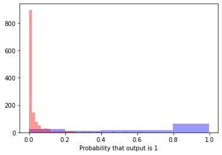

```python
#predicted probability distribution plot for personal_loan yes or no
sns.distplot(z[z['Actual'] == 1]['Probability that output is 1'],kde=False,color='b');
sns.distplot(z[z['Actual'] == 0]['Probability that output is 1'],kde=False,color='r');
```

```python
#metrics related to evaluating the model performance (accuracy, recall, precision, f1score, and roc_auc_score)

#accuracy
print("Trainig accuracy",model.score(x_train,y_train))
print()
print("Testing accuracy",model.score(x_test,y_test))
```

```
Trainig accuracy 0.958

Testing accuracy 0.964
```

```python
#recall
print("Recall for training data:",recall_score(y_train,model.predict(x_train)))
print("Recall for testing data:",recall_score(y_test,y_predict))
```

```
Recall for training data: 0.6666666666666666
Recall for testing data: 0.6739130434782609
```

```python
#precision
print("Precision for training data:",precision_score(y_train,model.predict(x_train)))
print("Precision for testing data:",precision_score(y_test,y_predict))
```

```
Precision for training data: 0.8735632183908046
Precision for testing data: 0.9117647058823529
```

```python
#f1-score
print("F1 Score for training data:",f1_score(y_train,model.predict(x_train)))
print("F1 Score for testing data:",f1_score(y_test,y_predict))
```

```
F1 Score for training data: 0.7562189054726368
F1 Score for testing data: 0.775
```

```python
#ROC score
print("Roc Auc Score for training data:",roc_auc_score(y_train,model.predict(x_train)))
print("Roc Auc Score for testing data:",roc_auc_score(y_test,y_predict))
```

```
Roc Auc Score for training data: 0.8281085074941946
Roc Auc Score for testing data: 0.833652556981421
```

```python
#confusion matrix and heatmap of it
cm = confusion_matrix(y_test,y_predict,labels=[1,0])
cm
```

```
array([[  93,   45],
       [   9, 1353]], dtype=int64)
```

```python
#dataframe for cm
df_cm = pd.DataFrame(cm,index=[i for i in ['True1','True0']],columns=[i for i in ['Predict1','Predict0']])
df_cm
```

|  | Predict1 | Predict0 |
| --- | --- | --- |
| True1 | 93 | 45 |
| True0 | 9 | 1353 |

```python
#function to get confusion matrix in a proper format
def draw_cm( actual, predicted ):
    cm = confusion_matrix( actual, predicted)
    sns.heatmap(cm, annot=True,  fmt='.2f', xticklabels = [0,1] , yticklabels = [0,1] )
    plt.ylabel('Observed')
    plt.xlabel('Predicted')
    plt.show()
```

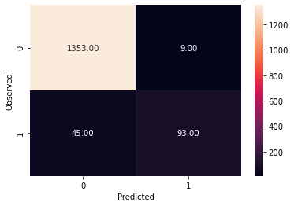

```python
#heatmap of confusion matrix
draw_cm(y_test,y_predict)
```

#### Insight:

*True Positive TP (observed=1,predicted=1) - 93:*

```
Predicted that the customer is likely to take personal loan and the customer finally ended up taking personal loan
```

*True Negative TN (observed=0,predicted=0) - 1353:*

```
Predicted that the customer is not likely to take personal loan and the customer finally ended up not taking personal loan
```

*False Positive FP (observed=0,predicted=1) - 9:*

```
Predicted that the customer is likely to take personal loan and the customer finally ended up not taking personal loan
```

*False Negative FN (observed=1,predicted=0) - 45:*

```
Predicted that the customer is not likely to take personal loan and the customer finally ended up taking personal loan
```

#### 5. Find out coefficients of all the attributes and show the output in a data frame with column names? For test data show all the rows where the predicted class is not equal to the observed class

```python
#coefficients from logistic regression model
df_coeff = pd.DataFrame(list(x_train.columns),columns=['Attribute'])
df_coeff.insert(len(df_coeff.columns),'coefficient',np.round(abs(model.coef_[0]),2))

df_coeff.sort_values(by='coefficient' , ascending=False)
```

|  | Attribute | coefficient |
| --- | --- | --- |
| 9 | Education_3 | 3.49 |
| 8 | Education_2 | 3.22 |
| 11 | CD_Account_1 | 2.33 |
| 6 | Family_3 | 1.72 |
| 7 | Family_4 | 1.46 |
| 13 | CreditCard_1 | 0.75 |
| 12 | Online_1 | 0.55 |
| 1 | Experience | 0.44 |
| 0 | Age | 0.43 |
| 5 | Family_2 | 0.37 |
| 3 | CCAvg | 0.13 |
| 10 | Securities_Account_1 | 0.11 |
| 2 | Income | 0.06 |
| 4 | Mortgage | 0.00 |

```python
#Coeff = 0
df_coeff[df_coeff['coefficient'] == 0]
```

|  | Attribute | coefficient |
| --- | --- | --- |
| 4 | Mortgage | 0.0 |

```python
#For test data show all the rows where the predicted class is not equal to the observed class
Z = x_test.copy()
Z['Personal_Loan_Actual'] = y_test
Z['Personal_Loan_Predicted'] = model.predict(x_test)

Z[Z['Personal_Loan_Actual'] != Z['Personal_Loan_Predicted']]
```

|  | Age | Experience | Income | CCAvg | Mortgage | Family_2 | Family_3 | Family_4 | Education_2 | Education_3 | Securities_Account_1 | CD_Account_1 | Online_1 | CreditCard_1 | Personal_Loan_Actual | Personal_Loan_Predicted |
| --- | --- | --- | --- | --- | --- | --- | --- | --- | --- | --- | --- | --- | --- | --- | --- | --- |
| 4301 | 49 | 24 | 130 | 1.10 | 281 | 0 | 0 | 1 | 0 | 0 | 0 | 1 | 1 | 0 | 1 | 0 |
| 4575 | 53 | 27 | 115 | 0.50 | 0 | 1 | 0 | 0 | 0 | 1 | 0 | 0 | 0 | 0 | 1 | 0 |
| 3383 | 46 | 22 | 135 | 4.10 | 213 | 0 | 1 | 0 | 0 | 0 | 0 | 0 | 1 | 0 | 1 | 0 |
| 459 | 35 | 10 | 200 | 3.00 | 458 | 1 | 0 | 0 | 0 | 0 | 0 | 0 | 0 | 0 | 0 | 1 |
| 1731 | 43 | 19 | 125 | 2.40 | 0 | 0 | 1 | 0 | 0 | 0 | 0 | 0 | 1 | 0 | 1 | 0 |
| 1901 | 43 | 19 | 201 | 6.67 | 0 | 1 | 0 | 0 | 0 | 0 | 1 | 0 | 1 | 0 | 0 | 1 |
| 2996 | 42 | 18 | 103 | 3.33 | 0 | 0 | 0 | 0 | 0 | 0 | 1 | 1 | 1 | 1 | 1 | 0 |
| 3983 | 39 | 13 | 93 | 3.60 | 0 | 0 | 0 | 1 | 0 | 1 | 0 | 0 | 1 | 0 | 1 | 0 |
| 1793 | 35 | 9 | 113 | 0.80 | 0 | 0 | 1 | 0 | 0 | 1 | 0 | 0 | 1 | 0 | 1 | 0 |
| 3612 | 50 | 25 | 99 | 4.60 | 368 | 0 | 0 | 0 | 0 | 0 | 1 | 1 | 0 | 1 | 1 | 0 |
| 183 | 29 | 3 | 148 | 4.10 | 0 | 0 | 1 | 0 | 0 | 0 | 0 | 0 | 1 | 0 | 1 | 0 |
| 737 | 64 | 37 | 138 | 2.80 | 0 | 1 | 0 | 0 | 1 | 0 | 0 | 0 | 1 | 0 | 1 | 0 |
| 2345 | 65 | 40 | 89 | 4.10 | 299 | 0 | 0 | 0 | 0 | 0 | 0 | 1 | 1 | 0 | 1 | 0 |
| 4702 | 35 | 5 | 108 | 2.75 | 0 | 1 | 0 | 0 | 0 | 1 | 1 | 0 | 0 | 0 | 1 | 0 |
| 4593 | 54 | 30 | 133 | 5.00 | 0 | 0 | 0 | 0 | 1 | 0 | 0 | 0 | 0 | 1 | 1 | 0 |
| 650 | 47 | 22 | 122 | 5.10 | 163 | 0 | 0 | 0 | 0 | 1 | 1 | 0 | 0 | 0 | 1 | 0 |
| 1062 | 47 | 21 | 83 | 3.80 | 97 | 0 | 0 | 0 | 0 | 0 | 0 | 0 | 0 | 0 | 1 | 0 |
| 1674 | 37 | 11 | 139 | 0.80 | 421 | 1 | 0 | 0 | 1 | 0 | 0 | 0 | 1 | 0 | 1 | 0 |
| 1328 | 60 | 36 | 145 | 6.90 | 380 | 0 | 0 | 1 | 0 | 0 | 0 | 0 | 0 | 1 | 1 | 0 |
| 3033 | 43 | 19 | 130 | 4.70 | 221 | 1 | 0 | 0 | 0 | 1 | 0 | 0 | 0 | 1 | 1 | 0 |
| 4151 | 44 | 18 | 123 | 5.90 | 0 | 0 | 1 | 0 | 0 | 0 | 0 | 1 | 1 | 1 | 1 | 0 |
| 2623 | 42 | 17 | 111 | 3.00 | 0 | 0 | 1 | 0 | 0 | 0 | 1 | 1 | 0 | 1 | 1 | 0 |
| 932 | 51 | 27 | 112 | 1.80 | 0 | 0 | 1 | 0 | 1 | 0 | 1 | 1 | 1 | 1 | 0 | 1 |
| 4225 | 43 | 18 | 204 | 8.80 | 0 | 1 | 0 | 0 | 0 | 0 | 0 | 0 | 1 | 0 | 0 | 1 |
| 2691 | 61 | 36 | 119 | 5.40 | 0 | 1 | 0 | 0 | 1 | 0 | 0 | 0 | 1 | 0 | 1 | 0 |
| 3959 | 43 | 19 | 123 | 1.30 | 0 | 0 | 1 | 0 | 0 | 0 | 0 | 0 | 1 | 0 | 1 | 0 |
| 1632 | 31 | 5 | 93 | 3.10 | 0 | 1 | 0 | 0 | 1 | 0 | 0 | 0 | 1 | 0 | 1 | 0 |
| 3030 | 50 | 26 | 110 | 1.80 | 0 | 0 | 1 | 0 | 1 | 0 | 0 | 0 | 1 | 0 | 0 | 1 |
| 2791 | 44 | 20 | 182 | 7.60 | 0 | 1 | 0 | 0 | 0 | 0 | 0 | 0 | 0 | 0 | 0 | 1 |
| 1166 | 30 | 5 | 112 | 5.00 | 0 | 0 | 0 | 1 | 1 | 0 | 0 | 0 | 0 | 1 | 1 | 0 |
| 4179 | 29 | 3 | 91 | 3.40 | 0 | 0 | 0 | 0 | 0 | 1 | 0 | 0 | 0 | 0 | 1 | 0 |
| 785 | 46 | 22 | 164 | 7.60 | 0 | 1 | 0 | 0 | 0 | 0 | 0 | 1 | 1 | 1 | 0 | 1 |
| 3988 | 59 | 35 | 85 | 3.40 | 0 | 0 | 0 | 0 | 0 | 1 | 0 | 1 | 0 | 1 | 1 | 0 |
| 1143 | 33 | 7 | 120 | 3.20 | 0 | 0 | 0 | 0 | 0 | 1 | 0 | 0 | 1 | 0 | 1 | 0 |
| 740 | 52 | 27 | 195 | 8.10 | 0 | 0 | 0 | 0 | 0 | 0 | 0 | 0 | 0 | 0 | 0 | 1 |
| 951 | 59 | 34 | 83 | 3.40 | 0 | 1 | 0 | 0 | 0 | 1 | 0 | 0 | 1 | 0 | 1 | 0 |
| 1918 | 39 | 9 | 118 | 6.00 | 246 | 1 | 0 | 0 | 0 | 1 | 0 | 1 | 1 | 1 | 1 | 0 |
| 4418 | 59 | 34 | 145 | 1.80 | 198 | 0 | 0 | 1 | 0 | 0 | 0 | 0 | 1 | 0 | 1 | 0 |
| 2586 | 47 | 23 | 149 | 6.10 | 0 | 0 | 0 | 1 | 0 | 0 | 0 | 0 | 0 | 1 | 1 | 0 |
| 891 | 32 | 6 | 120 | 5.40 | 301 | 0 | 0 | 1 | 0 | 0 | 0 | 1 | 1 | 1 | 1 | 0 |
| 1195 | 32 | 7 | 123 | 2.90 | 0 | 1 | 0 | 0 | 1 | 0 | 0 | 0 | 1 | 0 | 1 | 0 |
| 3478 | 31 | 6 | 133 | 1.50 | 0 | 0 | 0 | 0 | 0 | 1 | 0 | 0 | 0 | 0 | 1 | 0 |
| 438 | 58 | 32 | 113 | 3.80 | 119 | 1 | 0 | 0 | 1 | 0 | 0 | 1 | 1 | 1 | 1 | 0 |
| 3992 | 47 | 22 | 95 | 3.90 | 0 | 1 | 0 | 0 | 1 | 0 | 0 | 0 | 0 | 0 | 1 | 0 |
| 2001 | 44 | 17 | 128 | 3.25 | 0 | 1 | 0 | 0 | 1 | 0 | 0 | 0 | 0 | 1 | 1 | 0 |
| 2536 | 51 | 25 | 104 | 4.20 | 0 | 0 | 0 | 0 | 1 | 0 | 0 | 0 | 1 | 0 | 1 | 0 |
| 324 | 56 | 30 | 158 | 6.10 | 0 | 0 | 0 | 1 | 0 | 0 | 0 | 0 | 0 | 0 | 1 | 0 |
| 2391 | 39 | 12 | 138 | 4.67 | 0 | 0 | 0 | 0 | 1 | 0 | 0 | 0 | 1 | 0 | 1 | 0 |
| 3456 | 46 | 22 | 125 | 4.70 | 0 | 1 | 0 | 0 | 0 | 1 | 0 | 0 | 1 | 0 | 1 | 0 |
| 2194 | 34 | 9 | 123 | 1.60 | 0 | 0 | 0 | 0 | 1 | 0 | 0 | 0 | 1 | 0 | 1 | 0 |
| 1499 | 52 | 26 | 91 | 4.30 | 0 | 0 | 0 | 0 | 1 | 0 | 0 | 1 | 1 | 1 | 1 | 0 |
| 927 | 65 | 40 | 95 | 3.70 | 138 | 0 | 1 | 0 | 1 | 0 | 0 | 0 | 0 | 1 | 1 | 0 |
| 4163 | 54 | 28 | 108 | 1.90 | 0 | 0 | 0 | 1 | 1 | 0 | 0 | 0 | 1 | 0 | 1 | 0 |
| 2684 | 30 | 5 | 98 | 1.80 | 129 | 0 | 0 | 1 | 0 | 1 | 1 | 1 | 1 | 1 | 0 | 1 |

```python
len(Z[Z['Personal_Loan_Actual'] != Z['Personal_Loan_Predicted']])
```

```
54
```

#### Insight:

There are 54 rows in test dataset where actual value of y(personal_loan) not equal to predicted value of y(personal_loan)

#### 6. Give conclusion related to the Business understanding of your model?

#### Confusion matrix means:

*True Positive TP (observed=1,predicted=1) - 93:*

```
Predicted that the customer is likely to take personal loan and the customer finally ended up taking personal loan
```

*True Negative TN (observed=0,predicted=0) - 1353:*

```
Predicted that the customer is not likely to take personal loan and the customer finally ended up not taking personal loan
```

*False Positive FP (observed=0,predicted=1) - 9:*

```
Predicted that the customer is likely to take personal loan and the customer finally ended up not taking personal loan
```

*False Negative FN (observed=1,predicted=0) - 45:*

```
Predicted that the customer is not likely to take personal loan and the customer finally ended up taking personal loan
```

#### Important Features:

Based on the coefficient value, "Education_3", "Education_2", "CD_Account_1", "Family_3" and "Family_4" are the top 5 attributes that influence the model output

"Mortgage" has zero coefficient (shown above),so this feature don't help model in predicting target variable

#### Important Metric:

Here the bank wants to **predict the likelihood of a liability customer buying personal loan**

The model identifies **Education, CD Account and Family size** as important features to predict if a customer would take up personal loan

The model has **very low False Positive (FP)**, which means that customers who are likely to take personal loan ended up taking one

False positive also indicates this, the dataset provided had some customers that did not take personal loan, but the model predicts they are likely to take, bank can focus on this group to increase the number of personal loan customers

The model has higher True Negative (TN), which means that most of the bank customers are not likely to take personal loan

This model is built on a small dataset and shows higher values for all performance metrics. This can be run on a larger dataset and if the performance metrics are still good, bank can deploy this model for practical use, as in the bank can predict who is likely to take personal loan based on some of these features identified.

#### Model 2:

ZIP_Code is a category variable, eventhough the correlation shows a very small value and the plot of ZIP_Code does not show anything specific, wanted to try another model including County derived from ZIP_Code to see if it impacts the model

```python
#define x and y including the County field
x1 = dsBank.drop(columns=['Personal_Loan','ZIP_Code'],axis=1)
y1 = dsBank[['Personal_Loan']]
```

```python
#Convert categorical vriables to dummy variables
#drop_first reduces the number of columns and hence increases the computational time.
x1 = pd.get_dummies(x1, drop_first=True)
```

```python
x1_train,x1_test,y1_train,y1_test = train_test_split(x1,y1,test_size=0.30,random_state=7)
```

```python
#Logistic Regression
model_1 = LogisticRegression()
model_1.fit(x1_train,y1_train.values.ravel()) # fit the model on training data
```

```
LogisticRegression()
```

```python
#y prediction
y1_predict = model_1.predict(x1_test) # Predicting the target variable on test data
```

```python
#accuracy
print("Trainig accuracy",model_1.score(x1_train,y1_train))
print()
print("Testing accuracy",model_1.score(x1_test,y1_test))
```

```
Trainig accuracy 0.9585714285714285

Testing accuracy 0.9646666666666667
```

```python
#recall
print("Recall for training data:",recall_score(y1_train,model_1.predict(x1_train)))
print("Recall for testing data:",recall_score(y1_test,y1_predict))
```

```
Recall for training data: 0.6783625730994152
Recall for testing data: 0.6666666666666666
```

```python
#precision
print("Precision for training data:",precision_score(y1_train,model_1.predict(x1_train)))
print("Precision for testing data:",precision_score(y1_test,y1_predict))
```

```
Precision for training data: 0.8689138576779026
Precision for testing data: 0.9292929292929293
```

```python
#f1-score
print("F1 Score for training data:",f1_score(y1_train,model_1.predict(x1_train)))
print("F1 Score for testing data:",f1_score(y1_test,y1_predict))
```

```
F1 Score for training data: 0.7619047619047618
F1 Score for testing data: 0.7763713080168776
```

```python
#ROC score
print("Roc Auc Score for training data:",roc_auc_score(y1_train,model_1.predict(x1_train)))
print("Roc Auc Score for testing data:",roc_auc_score(y1_test,y1_predict))
```

```
Roc Auc Score for training data: 0.8336398045991059
Roc Auc Score for testing data: 0.830763582966226
```

```python
#coefficients from logistic regression model
df_coeff_1 = pd.DataFrame(list(x1_train.columns),columns=['Attribute'])
df_coeff_1.insert(len(df_coeff_1.columns),'coefficient',np.round(abs(model_1.coef_[0]),2))

df_coeff_1.sort_values(by='coefficient' , ascending=False)
```

|  | Attribute | coefficient |
| --- | --- | --- |
| 9 | Education_3 | 3.66 |
| 8 | Education_2 | 3.29 |
| 11 | CD_Account_1 | 2.49 |
| 6 | Family_3 | 1.69 |
| 7 | Family_4 | 1.61 |
| 13 | CreditCard_1 | 0.73 |
| 38 | County_San Mateo County | 0.69 |
| 12 | Online_1 | 0.55 |
| 40 | County_Santa Clara County | 0.50 |
| 28 | County_Orange County | 0.48 |
| 0 | Age | 0.43 |
| 1 | Experience | 0.43 |
| 34 | County_San Diego County | 0.42 |
| 5 | Family_2 | 0.36 |
| 33 | County_San Bernardino County | 0.30 |
| 49 | County_Ventura County | 0.22 |
| 44 | County_Solano County | 0.19 |
| 22 | County_Los Angeles County | 0.18 |
| 3 | CCAvg | 0.18 |
| 35 | County_San Francisco County | 0.17 |
| 45 | County_Sonoma County | 0.14 |
| 30 | County_Riverside County | 0.14 |
| 26 | County_Monterey County | 0.14 |
| 10 | Securities_Account_1 | 0.13 |
| 41 | County_Santa Cruz County | 0.13 |
| 51 | County_unknown | 0.12 |
| 16 | County_El Dorado County | 0.11 |
| 50 | County_Yolo County | 0.10 |
| 23 | County_Marin County | 0.08 |
| 29 | County_Placer County | 0.07 |
| 46 | County_Stanislaus County | 0.07 |
| 31 | County_Sacramento County | 0.06 |
| 17 | County_Fresno County | 0.06 |
| 15 | County_Contra Costa County | 0.05 |
| 2 | Income | 0.05 |
| 14 | County_Butte County | 0.05 |
| 36 | County_San Joaquin County | 0.04 |
| 20 | County_Kern County | 0.04 |
| 18 | County_Humboldt County | 0.04 |
| 25 | County_Merced County | 0.04 |
| 37 | County_San Luis Obispo County | 0.04 |
| 42 | County_Shasta County | 0.03 |
| 32 | County_San Benito County | 0.03 |
| 24 | County_Mendocino County | 0.01 |
| 21 | County_Lake County | 0.01 |
| 47 | County_Trinity County | 0.01 |
| 39 | County_Santa Barbara County | 0.00 |
| 19 | County_Imperial County | 0.00 |
| 27 | County_Napa County | 0.00 |
| 43 | County_Siskiyou County | 0.00 |
| 4 | Mortgage | 0.00 |
| 48 | County_Tuolumne County | 0.00 |

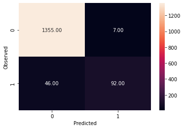

```python
#heatmap of confusion matrix
draw_cm(y1_test,y1_predict)
```

#### Insight from including County Info in model:

Looks like ZIP_Code is not adding to the model performace much based on the above analysis